# Report

Hafsa

2/2/2022

#load the packages

```r
library(caret)
library(rpart)
```

```r
library(rpart.plot)
library(RColorBrewer)
library(rattle)
library(randomForest)
```

#Load data Load the testing and training data

```r
training_csv<-read.csv('./pml-training.csv', header=T)
testing_csv<-read.csv('./pml-testing.csv', header=T)
```

# Data partiotion

```r
set.seed(12345)
inTrain<-createDataPartition(y=training_csv$classe, p=0.6, list=FALSE)
training<-training_csv[inTrain, ]
testing<-training_csv[-inTrain, ]
```

#Non zero data Identification on Non-Zero Data and will not use those data

```r
all_zero_colnames <- sapply(names(testing_csv), function(x) all(is.na(testing_csv[,x])==TRUE))
nznames <- names(all_zero_colnames)[all_zero_colnames==FALSE]
nznames <- nznames[-(1:7)]
nznames <- nznames[1:(length(nznames)-1)]
nznames
```

```
##  [1] "roll_belt"            "pitch_belt"           "yaw_belt"
##  [4] "total_accel_belt"     "gyros_belt_x"         "gyros_belt_y"
##  [7] "gyros_belt_z"         "accel_belt_x"         "accel_belt_y"
## [10] "accel_belt_z"         "magnet_belt_x"        "magnet_belt_y"
## [13] "magnet_belt_z"        "roll_arm"             "pitch_arm"
## [16] "yaw_arm"              "total_accel_arm"      "gyros_arm_x"
## [19] "gyros_arm_y"          "gyros_arm_z"          "accel_arm_x"
## [22] "accel_arm_y"          "accel_arm_z"          "magnet_arm_x"
## [25] "magnet_arm_y"         "magnet_arm_z"         "roll_dumbbell"
## [28] "pitch_dumbbell"       "yaw_dumbbell"         "total_accel_dumbbell"
## [31] "gyros_dumbbell_x"     "gyros_dumbbell_y"     "gyros_dumbbell_z"
## [34] "accel_dumbbell_x"     "accel_dumbbell_y"     "accel_dumbbell_z"
## [37] "magnet_dumbbell_x"    "magnet_dumbbell_y"    "magnet_dumbbell_z"
## [40] "roll_forearm"         "pitch_forearm"        "yaw_forearm"
## [43] "total_accel_forearm"  "gyros_forearm_x"      "gyros_forearm_y"
## [46] "gyros_forearm_z"      "accel_forearm_x"      "accel_forearm_y"
## [49] "accel_forearm_z"      "magnet_forearm_x"     "magnet_forearm_y"
## [52] "magnet_forearm_z"
```

#Cross validation Cross validation is done for each model with K = 3. This is set in the above code chunk using the fitControl object as defined below:

```r
fitControl <- trainControl(method='cv', number = 3)
```

#Model building The three model types I’m going to test are: Decision trees with CART (rpart) Stochastic gradient boosting trees (gbm) Random forest decision trees (rf) # Decision trees with CART (rpart)

[figure not shown]

```r
mod_CART <- train(classe ~ ., data = training[, c('classe', nznames)], trControl=fitControl,method = "rpart")
predCART <- predict(mod_CART, newdata=testing)
cmCART <- confusionMatrix(predCART,factor(testing$classe))
fancyRpartPlot(mod_CART$finalModel)
```

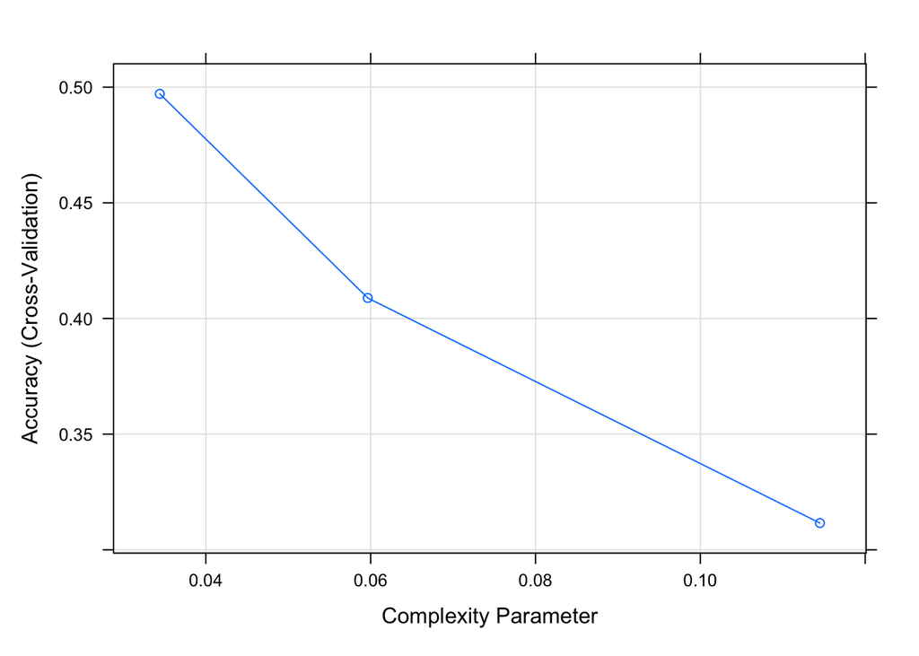

```r
plot(mod_CART)
```

#Stochastic gradient boosting trees (gbm)

```r
mod_gbm <- train(classe ~ ., data = training[, c('classe', nznames)], trControl=fitControl,method = "gbm")
```

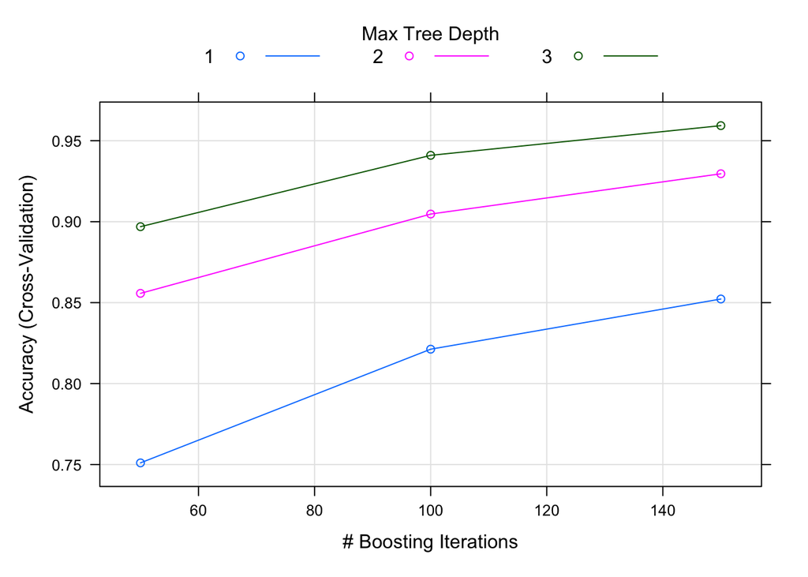

```r
predgbm <- predict(mod_gbm, newdata=testing)
cmgbm <- confusionMatrix(predgbm,factor(testing$classe))
plot(mod_gbm)
```

#Random forest decision trees (rf)

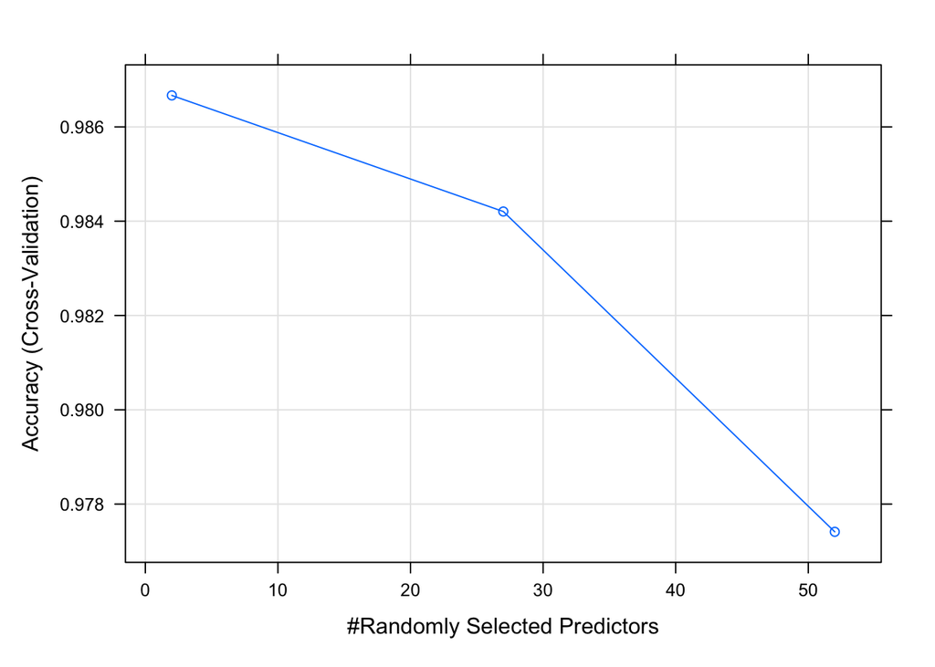

```r
mod_rf <- train(classe ~ ., data = training[, c('classe', nznames)], trControl=fitControl,method = "rf")
predrf <- predict(mod_rf, newdata=testing)
cmrf <- confusionMatrix(predrf,factor(testing$classe))
plot(mod_rf)
```

#Model assesment

```r
AccuracyResults <- data.frame(
  Model = c('CART', 'GBM', 'RF'),
  Accuracy = rbind(cmCART$overall[1], cmgbm$overall[1], cmrf$overall[1])
)
print(AccuracyResults)
```

```
##   Model  Accuracy
## 1  CART 0.4974509
## 2   GBM 0.9645679
## 3    RF 0.9947744
```

Random foirest is the champion model with accuracy level 99%.

#Prediction As a last step in the project, I’ll use the validation data sample (‘pml-testing.csv’) to predict a classe for each of the 20 observations based on the other information we know about these observations contained in the validation sample.

```r
predValidation <- predict(mod_rf, newdata=testing_csv)
ValidationPredictionResults <- data.frame(
  problem_id=testing_csv$problem_id,
  predicted=predValidation
)
print(ValidationPredictionResults)
```

```
##    problem_id predicted
## 1           1         B
## 2           2         A
## 3           3         B
## 4           4         A
## 5           5         A
## 6           6         E
## 7           7         D
## 8           8         B
## 9           9         A
## 10         10         A
## 11         11         B
## 12         12         C
## 13         13         B
## 14         14         A
## 15         15         E
## 16         16         E
## 17         17         A
## 18         18         B
## 19         19         B
## 20         20         B
```

#Conclusion Based on the data available, I am able to fit a reasonably sound model with a high degree of accuracy in predicting out of sample observations. I limit features to those that are non-zero in the validation sample.